# Task2_RNAseq_Analysis

Tram Nguyen

2023-08-25

```r
library(CCBcodingTasks)
```

## Analysis of bulk RNA-seq data

This vignette includes code for the second task to analyze RNA-seq data using the airway package.

First, let’s load the necessary packages. Obtain bulk RNA-seq data from human airway smooth muscle cells from the airway package.

```r
# BiocManager::install('airway') BiocManager::install(SummarizedExperiment)

library(SummarizedExperiment)
library(airway)
library(dplyr)
library(reshape2)
library(tibble)

# load data and view it
data(airway)
se <- airway

# RangedSummarizedExperiment object of read counts in genes for an RNA-Seq experiment on four human
# airway smooth muscle cell lines treated with dexamethasone
```

First, familiarize ourselves with the data.

```r
# View experiment and sample information.
colData(se)
```

```
#> DataFrame with 8 rows and 9 columns
#>            SampleName     cell      dex    albut        Run avgLength
#>              <factor> <factor> <factor> <factor>   <factor> <integer>
#> SRR1039508 GSM1275862  N61311     untrt    untrt SRR1039508       126
#> SRR1039509 GSM1275863  N61311     trt      untrt SRR1039509       126
#> SRR1039512 GSM1275866  N052611    untrt    untrt SRR1039512       126
#> SRR1039513 GSM1275867  N052611    trt      untrt SRR1039513        87
#> SRR1039516 GSM1275870  N080611    untrt    untrt SRR1039516       120
#> SRR1039517 GSM1275871  N080611    trt      untrt SRR1039517       126
#> SRR1039520 GSM1275874  N061011    untrt    untrt SRR1039520       101
#> SRR1039521 GSM1275875  N061011    trt      untrt SRR1039521        98
#>            Experiment    Sample    BioSample
#>              <factor>  <factor>     <factor>
#> SRR1039508  SRX384345 SRS508568 SAMN02422669
#> SRR1039509  SRX384346 SRS508567 SAMN02422675
#> SRR1039512  SRX384349 SRS508571 SAMN02422678
#> SRR1039513  SRX384350 SRS508572 SAMN02422670
#> SRR1039516  SRX384353 SRS508575 SAMN02422682
#> SRR1039517  SRX384354 SRS508576 SAMN02422673
#> SRR1039520  SRX384357 SRS508579 SAMN02422683
#> SRR1039521  SRX384358 SRS508580 SAMN02422677
```

```r
# View the gene information.
rowData(se)  # 64102 gene names
```

```
#> DataFrame with 64102 rows and 0 columns
```

### 1. Subset the airway dataset to genes (rows) with at least 8 reads mapped across all samples (columns).

```r
# Access the read count matrix of the experiment - For the airway dataset there is only one assay.
Count <- assay(se)
head(Count)
```

```
#>                 SRR1039508 SRR1039509 SRR1039512 SRR1039513 SRR1039516
#> ENSG00000000003        679        448        873        408       1138
#> ENSG00000000005          0          0          0          0          0
#> ENSG00000000419        467        515        621        365        587
#> ENSG00000000457        260        211        263        164        245
#> ENSG00000000460         60         55         40         35         78
#> ENSG00000000938          0          0          2          0          1
#>                 SRR1039517 SRR1039520 SRR1039521
#> ENSG00000000003       1047        770        572
#> ENSG00000000005          0          0          0
#> ENSG00000000419        799        417        508
#> ENSG00000000457        331        233        229
#> ENSG00000000460         63         76         60
#> ENSG00000000938          0          0          0
```

```r
# Identify rows where read count is greater than or equal to 8
row_indices <- apply(Count, 1, function(row) all(row >= 8))

# How many genes remain after our filtering?
length(which(row_indices == T))  #14644
```

```
#> [1] 14644
```

```r
# Filter matrix based on identified rows
filtered_mat <- Count[row_indices, ]

# Check the new matrix to make sure it only includes 14644 genes that passed.
dim(filtered_mat)
```

```
#> [1] 14644     8
```

```r
head(filtered_mat)
```

```
#>                 SRR1039508 SRR1039509 SRR1039512 SRR1039513 SRR1039516
#> ENSG00000000003        679        448        873        408       1138
#> ENSG00000000419        467        515        621        365        587
#> ENSG00000000457        260        211        263        164        245
#> ENSG00000000460         60         55         40         35         78
#> ENSG00000000971       3251       3679       6177       4252       6721
#> ENSG00000001036       1433       1062       1733        881       1424
#>                 SRR1039517 SRR1039520 SRR1039521
#> ENSG00000000003       1047        770        572
#> ENSG00000000419        799        417        508
#> ENSG00000000457        331        233        229
#> ENSG00000000460         63         76         60
#> ENSG00000000971      11027       5176       7995
#> ENSG00000001036       1439       1359       1109
```

### 2. Scale the read counts in each sample by library size.

```r
# Create a function to divide read counts by the library size (sum of each column) multiplied by
# 10^6 to obtain counts per million reads mapped

scaleCounts <- function(mat) {
    col_sums <- colSums(mat)
    normalized_mat <- (mat/col_sums) * 10^6
    return(normalized_mat)
}

# Use the function on our filtered matrix above
normalized_mat <- scaleCounts(filtered_mat)

# Check that the read counts were changed correctly
head(normalized_mat)
```

```
#>                 SRR1039508 SRR1039509 SRR1039512 SRR1039513 SRR1039516
#> ENSG00000000003  33.006822   18.38290  42.437342  16.741569  55.319239
#> ENSG00000000419  24.902827   16.76157  33.114894  11.879563  31.301840
#> ENSG00000000457  10.289684   11.06460  10.408411   8.599974   9.696049
#> ENSG00000000460   3.968369    2.60534   2.645579   1.657944   5.158879
#> ENSG00000000971 133.399118  178.83961 253.462427 206.693677 275.784519
#> ENSG00000001036  46.639488   56.63127  56.403512  46.979423  46.346567
#>                 SRR1039517 SRR1039520 SRR1039521
#> ENSG00000000003  42.961820   37.43042  23.471023
#> ENSG00000000419  26.004851   22.23657  16.533747
#> ENSG00000000457  17.357265    9.22114  12.008500
#> ENSG00000000460   2.984299    5.02660   2.842189
#> ENSG00000000971 536.032731  212.38814 388.644389
#> ENSG00000001036  76.734835   44.23103  59.137548
```

### 3. Subset the resulting SummarizedExperiment, containing counts per million reads mapped, to the first one hundred genes.

```r
# Grab the first 100 rows (genes)
mat100 <- normalized_mat[1:100, ]

# Check the dimensions
dim(mat100)
```

```
#> [1] 100   8
```

```r
head(mat100)
```

```
#>                 SRR1039508 SRR1039509 SRR1039512 SRR1039513 SRR1039516
#> ENSG00000000003  33.006822   18.38290  42.437342  16.741569  55.319239
#> ENSG00000000419  24.902827   16.76157  33.114894  11.879563  31.301840
#> ENSG00000000457  10.289684   11.06460  10.408411   8.599974   9.696049
#> ENSG00000000460   3.968369    2.60534   2.645579   1.657944   5.158879
#> ENSG00000000971 133.399118  178.83961 253.462427 206.693677 275.784519
#> ENSG00000001036  46.639488   56.63127  56.403512  46.979423  46.346567
#>                 SRR1039517 SRR1039520 SRR1039521
#> ENSG00000000003  42.961820   37.43042  23.471023
#> ENSG00000000419  26.004851   22.23657  16.533747
#> ENSG00000000457  17.357265    9.22114  12.008500
#> ENSG00000000460   2.984299    5.02660   2.842189
#> ENSG00000000971 536.032731  212.38814 388.644389
#> ENSG00000001036  76.734835   44.23103  59.137548
```

### 4. Test for differences between the dexamethasone treated and untreated sample groups.

I am going to begin by updating our SummarizedExperiment object to include just the first 100 filtered genes that we’ve already normalized by library size.

```r
# Update the our SummarizedExperiment object to include genes in the subsetted assay matrix

# Find row indices in original dataset that are not present in the filtered
non_matching_indices <- which(!(rownames(se) %in% rownames(mat100)))

# Filter out the rows
new_se <- se[-non_matching_indices, ]
new_se  #top 100 genes that are normalized by library size.
```

```
#> class: RangedSummarizedExperiment
#> dim: 100 8
#> metadata(1): ''
#> assays(1): counts
#> rownames(100): ENSG00000000003 ENSG00000000419 ... ENSG00000006282
#>   ENSG00000006327
#> rowData names(0):
#> colnames(8): SRR1039508 SRR1039509 ... SRR1039520 SRR1039521
#> colData names(9): SampleName cell ... Sample BioSample
```

```r
# Now replace with our noramlized matrix.
assay(new_se) <- mat100
head(assay(new_se))
```

```
#>                 SRR1039508 SRR1039509 SRR1039512 SRR1039513 SRR1039516
#> ENSG00000000003  33.006822   18.38290  42.437342  16.741569  55.319239
#> ENSG00000000419  24.902827   16.76157  33.114894  11.879563  31.301840
#> ENSG00000000457  10.289684   11.06460  10.408411   8.599974   9.696049
#> ENSG00000000460   3.968369    2.60534   2.645579   1.657944   5.158879
#> ENSG00000000971 133.399118  178.83961 253.462427 206.693677 275.784519
#> ENSG00000001036  46.639488   56.63127  56.403512  46.979423  46.346567
#>                 SRR1039517 SRR1039520 SRR1039521
#> ENSG00000000003  42.961820   37.43042  23.471023
#> ENSG00000000419  26.004851   22.23657  16.533747
#> ENSG00000000457  17.357265    9.22114  12.008500
#> ENSG00000000460   2.984299    5.02660   2.842189
#> ENSG00000000971 536.032731  212.38814 388.644389
#> ENSG00000001036  76.734835   44.23103  59.137548
```

We can see that the new_se SummarizedExperiment object is updated with just the top 100 genes that passed our previous filtering.

```r
# Split SummarizedExperiment by treatment groups
trt <- new_se[, new_se$dex == "trt"]  # treated
untrt <- new_se[, new_se$dex == "untrt"]  # untreated
```

Now, for each gene in our 100 top genes, do a t.test between the two groups.

```r
# First, make a new column in rowData to store your P-values.
rowData(new_se)$pval <- NA

# loop through each gene, and update the pval column with the results of the t.test comparing the
# two groups.
for (i in 1:nrow(assay(new_se))) {

    # loop through each gene in our SummarizedExperiment object. Extract current gene.
    c.gene <- rownames(new_se[i])

    # For the current gene, perform a t.test between the sample groups, adjusting for multiple
    # correction.
    result <- t.test(assay(trt[c.gene, ]), assay(untrt[c.gene, ]))

    # Add the p.value to our rowData in our SummarizedExperiment object.
    rowData(new_se)$pval[i] <- as.numeric(result$p.value)

}

# View your updated row information with the P-values for each gene.
head(rowData(new_se))
```

```
#> DataFrame with 6 rows and 1 column
#>                      pval
#>                 <numeric>
#> ENSG00000000003 0.0765583
#> ENSG00000000419 0.0429449
#> ENSG00000000457 0.2928810
#> ENSG00000000460 0.0560800
#> ENSG00000000971 0.2928764
#> ENSG00000001036 0.1637471
```

NOTE: In the future, we may want to adjust our P-values for multiple testing using something like Bonferroni or Tukey corrections, but for now we will use the raw P-Values.

### 5. Finally, make graphical summaries for the top5 differentially expressed genes.

We will 1) make a boxplot that shows expression differences between the two sample groups for each of the top genes, and 2) calculate log2 fold change and graph the change in gene expression across the groups using a Volcano plot.

We are going to manipulate the read count data for the top 5 genes into a combined data frame in long format for plotting purposes.

```r
# Grab the top 5 signficant p values
Topvals <- sort(rowData(new_se)$pval, decreasing = F)[1:5]
topidx <- which(rowData(new_se)$pval %in% Topvals)

# Subset to just the top5 genes
top5 <- new_se[topidx]

# Extract treatment groups for just the top 5 genes
trt5 <- top5[, top5$dex == "trt"]  # treated
untrt5 <- top5[, top5$dex == "untrt"]  # untreated
# For each gene make a boxplot comparing the two groups

# Convert to dataframe for ease of plotting
trt5 <- as.data.frame(assay(trt5))
trt5$Condition <- "Treated"
untrt5 <- as.data.frame(assay(untrt5))
untrt5$Condition <- "Untreated"

# Function to convert count data into a combined dataframe in long format for plotting
edit_df <- function(df) {

    df %>%
        rownames_to_column(var = "GeneID") %>%
        melt(id.vars = c("Condition", "GeneID"), variable.name = "Sample", value.name = "ReadCount")

}

# Combine the data frames into a list and apply the function.
combo.list <- list(trt5, untrt5)
combo.list <- lapply(combo.list, edit_df)

# Combined the edited dataframes together into one
combo5 <- data.frame(do.call(rbind, combo.list))
head(combo5)
```

```
#>   Condition          GeneID     Sample ReadCount
#> 1   Treated ENSG00000005020 SRR1039509 25.419009
#> 2   Treated ENSG00000005059 SRR1039509  9.331854
#> 3   Treated ENSG00000005189 SRR1039509  2.544062
#> 4   Treated ENSG00000006025 SRR1039509  6.252816
#> 5   Treated ENSG00000006114 SRR1039509 28.138329
#> 6   Treated ENSG00000005020 SRR1039513 18.095991
```

**For the first plot,** create boxplots of the scaled read count across the treatment groups.

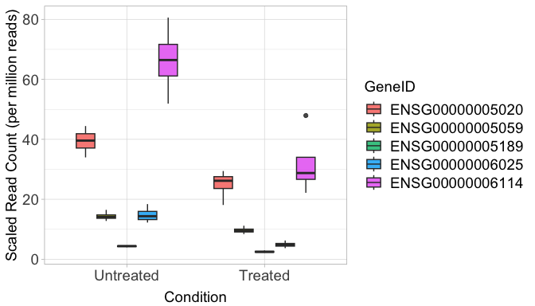

```r
library(ggplot2)

# Reorder so untreated is shown first
combo5$Condition <- factor(combo5$Condition, levels = c("Untreated", "Treated"))
combo5 <- combo5[order(combo5$Condition), ]

# Basic box plot of scaled read counts
p1 <- ggplot(combo5, aes(x = Condition, y = ReadCount, fill = GeneID)) + geom_boxplot(alpha = 0.85) +
    theme_light() + ylab("Scaled Read Count (per million reads)") + theme(legend.title = element_text(size = 14),
    legend.text = element_text(size = 14)) + theme(axis.title.x = element_text(size = 14, vjust = -0.5),
    axis.title.y = element_text(size = 14)) + theme(axis.text.x = element_text(size = 14), axis.text.y = element_text(size = 14))

print(p1)
```

*Interpretation: Generally, for the top 5 most significantly differential expressed genes, read count was lower in the group treated with dexamethasone.*

**For the second plot,** we can quickly calculate expression across the groups by looking at log2 fold change and make a Volcano plot. We can do this more robustly using another package like DESeq2 of course, but for this task, I will just calculate the ratio of treated versus untreated by hand and plot it against the P-values we have already calculated in Step 4. To fill in our Volcano plot, I will use all 100 of our previously subsetted genes, and color the top 5 most significantly DE genes in red.

```r
# Make our assay read counts into a data frame
new_se.df <- as.data.frame(assay(new_se))

# Grab sample IDs and their indices belonging to each group.
treatSamps <- colnames(trt5)[1:4]
t.idx <- which(colnames(new_se.df) %in% treatSamps)

untreatSamps <- colnames(untrt5)[1:4]
u.idx <- which(colnames(new_se.df) %in% untreatSamps)

# Calculate log2 fold change for each gene in our 100 gene subset. Start by getting the mean read
# count of each gene per group. Then divide treatment mean with untreated mean to get a ratio of
# gene expression change. Finally, log2 that ratio.

# Create a dataframe that we will populate with for loop.
Log2FC.df <- data.frame(Gene = rowData(new_se), Log2FC = NA)


for (i in 1:nrow(new_se.df)) {

    c.df <- new_se.df[i, ]  # For each gene at a time
    tmean <- rowMeans(c.df[, t.idx], na.rm = TRUE)  # Caluclate treated mean
    untmean <- rowMeans(c.df[, u.idx], na.rm = TRUE)  # Caluclate untreated mean
    Log2ratExp <- log2(tmean/untmean)  # get Log2 ratio
    gene <- rownames(new_se.df[i, ])
    Log2FC.df$Log2FC[i] <- Log2ratExp  # Populate 100 gene dataframe

}
```

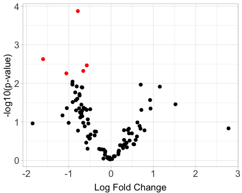

```r
# Create a volcano plot
volcano.p <- ggplot(Log2FC.df, aes(x = Log2FC, y = -log10(pval))) + geom_point(aes(color = ifelse(rownames(Log2FC.df) %in%
    rownames(top5), "red", "black")), size = 2) + scale_color_manual(values = c("black", "red")) + xlab("Log Fold Change") +
    ylab("-log10(p-value)") + theme_light() + theme(legend.position = "none") + theme(axis.title.x = element_text(size = 14,
    vjust = -0.5), axis.title.y = element_text(size = 14)) + theme(axis.text.x = element_text(size = 14),
    axis.text.y = element_text(size = 14))


# Display the volcano plot
print(volcano.p)
```

*Here we can see the top 5 most significantly differentiated genes are colored in red and appear to have lower expression within the treatment group compared to the untreated group (Log Fold Change on the X-axis).*